# Chapter 8. Markov Chain Monte Carlo

16/05/2022

Here we’ll solve the exercises for the chapter.

```r
library(rethinking)
library(magrittr)
library(data.table)
```

## Easy

### 9E1

Which of the following is a requirement of the simple Metropolis algorithm? (1) The parameters must be discrete. (2) The likelihood function must be Gaussian. (3) The proposal distribution must be symmetric.

**Answer:** Number 3, the proposal must be symmetric. Parameters need not to be discrete, and the distribution need not to be Gaussian – that’s the point in using MCMC algorithms: model distributions that are not necessary Gaussian.

### 9E2

Gibbs sampling is more efficient than the Metropolis algorithm. How does it achieve this extra efficiency? Are there any limitations to the Gibbs sampling strategy?

**Answer:** Gibbs sampling achieves extra efficiency by allowing for asymmetric proposals, whereby proposals are adaptive, and depend upon the parameter values at the moment. Limitations to the Gibbs sampling include models with a high number of parameters, where both Gibbs and Metropolis get stuck in high probability regions – this problem is also known as concentration of measure.

###9E3

Which sort of parameters can Hamiltonian Monte Carlo not handle? Can you explain why?

**Answer:** HMC requires continuous parameters. The reason is that HMC runs a physics simulation, pretending that the vector of parameters give the position of a little frictionless particle. This particle must be allowed to stop at any point, thus the surface it moves need to be continuous.

###9E4

Explain the difference between the effective number of samples, n_eff as calculated by Stan, and the actual number of samples.

**Answer:** Numbers of samples refers to the total number of samples picked by the algorithm, whereas the *effective* number of samples refers to a crude estimate of the number of *independent* samples. The difference lies in that many of the samples would be highly correlated, and will thus be little informative. By using independent samples we ensure we’re extracting as much information as we can.

###9E5

Which value should Rhat approach, when a chain is sampling the posterior distribution correctly?

**Answer:** It should approach 1.00 from above.

###9E6

Sketch a good trace plot for a Markov chain, one that is effectively sampling from the posterior distribution. What is good about its shape? Then sketch a trace plot for a malfunctioning Markov chain. What about its shape indicates malfunction?

**Answer:** Imagine I’m sketching…

Good trace plot: Sideways trend, most samples falling near the trendline, giving the graph a caterpillar shape. Bad trace plot: Upwards or downwards (or irregular) trend. Some samples falling very far away from the trend.

###9E7

Repeat the problem above, but now for a trace rank plot.

**Answer:** Imagine I’m sketching…

Good trace rank plot: Histograms that overlap and stay within the same range. Bad trace rank plot: Histograms that spend long periods with one chain above or below the others.

##Medium

###9M1

Re-estimate the terrain ruggedness model from the chapter, but now using a uniform prior for the standard deviation, sigma. The uniform prior should be dunif(0,1). Use ulam to estimate the posterior. Does the different prior have any detectible influence on the posterior distribution of sigma? Why or why not?

#9M2

Modify the terrain ruggedness model again. This time, change the prior for b[cid] to dexp(0.3). What does this do to the posterior distribution? Can you explain it?

###9M3

Re-estimate one of the Stan models from the chapter, but at different numbers of warmup iterations. Be sure to use the same number of sampling iterations in each case. Compare the n_eff values. How much warmup is enough?

###9H1

Run the model below and then inspect the posterior distribution and explain what it is accomplishing.

```r
mp <- ulam(
alist(
a ~ dnorm(0,1),
b ~ dcauchy(0,1)
), data=list(y=1) , chains=1 )
```

```
## Trying to compile a simple C file
```

[output not shown]

Compare the samples for the parameters a and b. Can you explain the different trace plots? If you are unfamiliar with the Cauchy distribution, you should look it up. The key feature to attend to is that it has no expected value. Can you connect this fact to the trace plot?

**Answer:** Let’s do it!

```r
precis(mp)
```

```
##         mean         sd      5.5%     94.5%    n_eff    Rhat4
## a 0.07209883  0.9963071 -1.373545  1.733345 234.2805 0.998023
## b 0.84907853 19.5795139 -6.067318 20.269265 139.0766 0.998051
```

```
## [1] 1000
## [1] 1
## [1] 1000
```

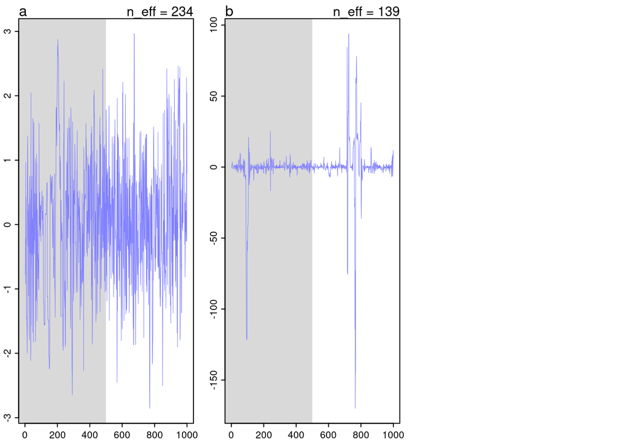

```r
traceplot(mp)
```

We see an apparently healthy (a) and pathological (b) traceplots. “A” comes from a normal prior distribution with weakly informative priors, and show the typical caterpillar shape, with most samples being around the mean. On the other hand, “b” has many samples very far away from the mean, meaning that it’s exploring the posterior poorly. Unsurprisingly, the process generating the data has a Cauchy distribution. The Cauchy distribution is often used in statistics as the canonical example of a “pathological” distribution since both its expected value and its variance are undefined. In a nutshell, using a Cauchy distribution in this case is akin to using flat priors, hence the pathological trace plot.

###9H2

Recall the divorce rate example from Chapter 5. Repeat that analysis, using ulam this time, fitting models m5.1, m5.2, and m5.3. Use compare to compare the models on the basis of WAIC or PSIS. To use WAIC or PSIS with ulam, you need add the argument log_log=TRUE. Explain the model comparison results.

**Answer:** Let’s go!

```r
# load data and copy
data(WaffleDivorce)
d <- WaffleDivorce
# standardize variables
d$D <- standardize( d$Divorce )
d$M <- standardize( d$Marriage )
d$A <- standardize( d$MedianAgeMarriage )

# Simplify input
d <- d[, c("Location","D", "M", "A")]

# m5.1 considers median age at marriage as the only predictor
m5.1 <- ulam(
alist(
  D ~ dnorm( mu , sigma ) ,
  mu <- a + bA * A ,
  a ~ dnorm( 0 , 0.2 ) ,
  bA ~ dnorm( 0 , 0.5 ) ,
  sigma ~ dexp( 1 )
) , data = d, chains = 4, cores = 4, log_lik = TRUE )
```

```
## Trying to compile a simple C file
```

[output not shown]

```r
# m5.2 considers marriage rate as the only predictor
m5.2 <- ulam(
alist(
D ~ dnorm( mu , sigma ) ,
mu <- a + bM * M ,
a ~ dnorm( 0 , 0.2 ) ,
bM ~ dnorm( 0 , 0.5 ) ,
sigma ~ dexp( 1 )
) , data = d, chains = 4, cores = 4, log_lik = TRUE  )
```

```
## Trying to compile a simple C file
```

[output not shown]

```r
# m5.2 considers marriage rate and median age at marriage as predictors
m5.3 <- ulam(
alist(
D ~ dnorm( mu , sigma ) ,
mu <- a + bM*M + bA*A ,
a ~ dnorm( 0 , 0.2 ) ,
bM ~ dnorm( 0 , 0.5 ) ,
bA ~ dnorm( 0 , 0.5 ) ,
sigma ~ dexp( 1 )
) , data = d , chains = 4, cores = 4, log_lik = TRUE)
```

```
## Trying to compile a simple C file
```

[output not shown]

```
## [1] 1000
## [1] 1
## [1] 1000
```

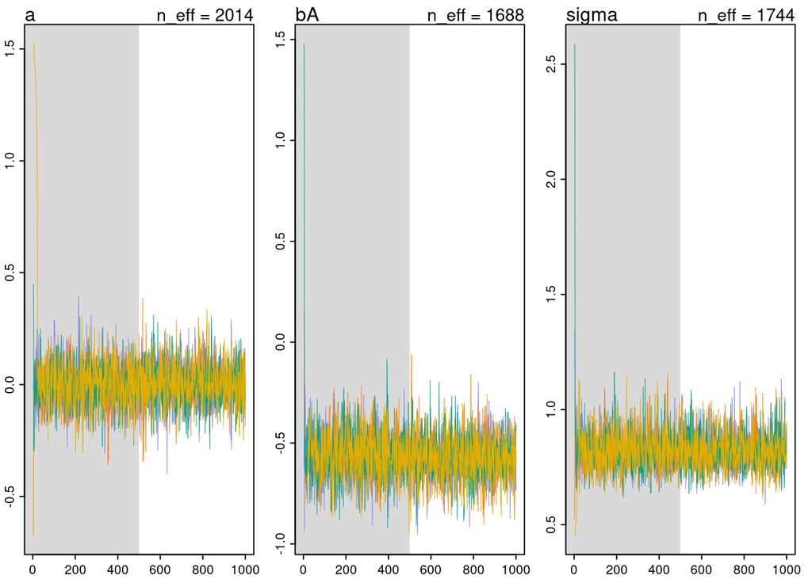

```r
traceplot(m5.1)
```

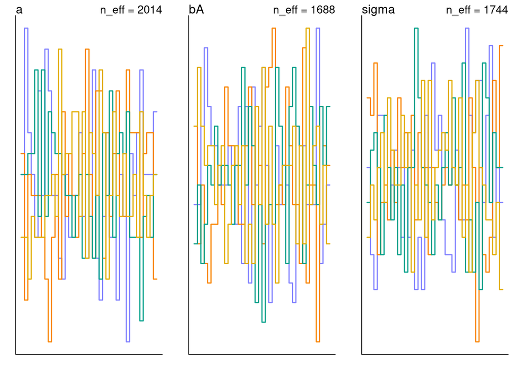

```r
trankplot(m5.1)
```

```r
precis(m5.1)
```

```
##               mean         sd       5.5%      94.5%    n_eff     Rhat4
## a      0.002256235 0.09977248 -0.1504852  0.1593371 2014.082 1.0008593
## bA    -0.573197426 0.11410866 -0.7574799 -0.3940199 1687.573 1.0021301
## sigma  0.820853445 0.08176384  0.7020286  0.9621081 1744.181 0.9994207
```

```
## [1] 1000
## [1] 1
## [1] 1000
```

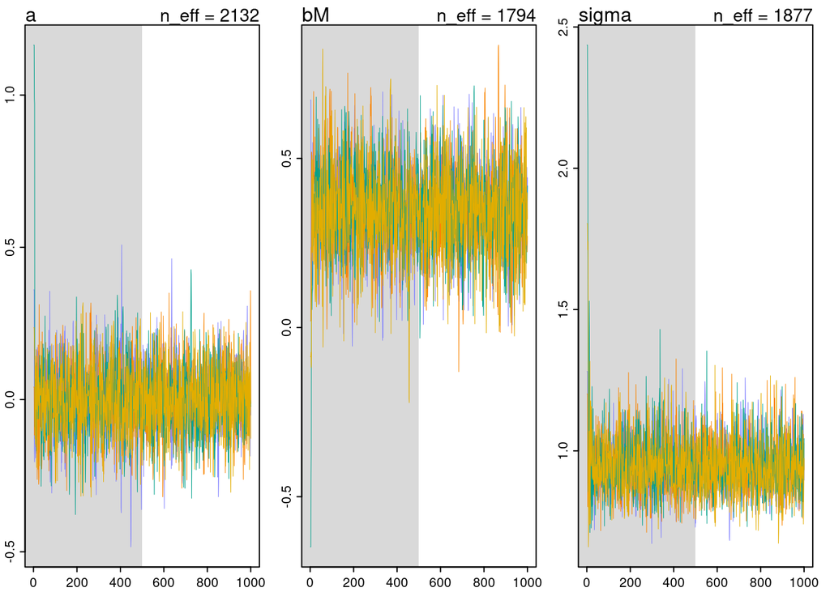

```r
traceplot(m5.2)
```

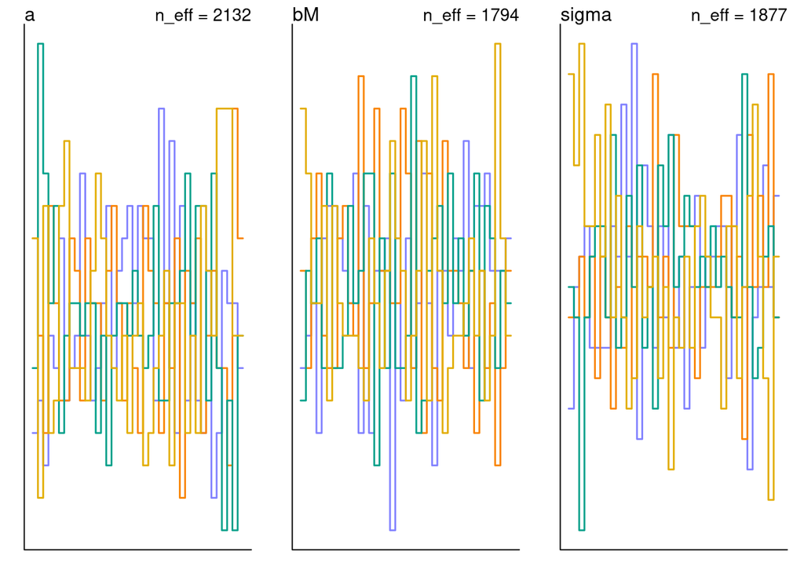

```r
trankplot(m5.2)
```

```r
precis(m5.2)
```

```
##              mean         sd       5.5%     94.5%    n_eff     Rhat4
## a     0.002506628 0.10894401 -0.1715921 0.1753389 2132.162 0.9990960
## bM    0.343998938 0.13522983  0.1233478 0.5600997 1793.991 0.9992558
## sigma 0.945658348 0.09368217  0.8055502 1.1045490 1876.742 1.0003180
```

```r
traceplot(m5.3)
```

```
## [1] 1000
## [1] 1
## [1] 1000
```

[figure not shown]

```r
trankplot(m5.3)
```

```r
precis(m5.3)
```

```
##                mean         sd       5.5%      94.5%    n_eff    Rhat4
## a      0.0002711611 0.10130499 -0.1602225  0.1640192 1678.784 1.003110
## bM    -0.0643834994 0.15915034 -0.3114778  0.1898712 1011.741 1.005777
## bA    -0.6082359057 0.15968632 -0.8648049 -0.3467548 1157.111 1.002085
## sigma  0.8262188387 0.08688633  0.7023609  0.9766078 1149.975 1.003673
```

[figure not shown]

Models diagnostics look good! Let’s compare them

```r
compare(m5.1, m5.2, m5.3, func = PSIS)
```

```
## Some Pareto k values are high (>0.5). Set pointwise=TRUE to inspect individual points.
## Some Pareto k values are high (>0.5). Set pointwise=TRUE to inspect individual points.
```

```
##          PSIS        SE    dPSIS       dSE    pPSIS      weight
## m5.1 125.4392 12.786067  0.00000        NA 3.509862 0.777260497
## m5.3 127.9455 13.036815  2.50632 0.8340443 4.944517 0.221986328
## m5.2 139.3177  9.967151 13.87847 9.3404298 2.987247 0.000753175
```

Using ulam, the model using median age at marriage as the only predictor seems to be the best one, outperforming m5.3, which includes marriage rate. These results are similar to those obtained with quap, but now m5.1 gets even more weight than before

###9H3

Sometimes changing a prior for one parameter has unanticipated effects on other parameters. This is because when a parameter is highly correlated with another parameter in the posterior, the prior influences both parameters. Here’s an example to work and think through. Go back to the leg length example in Chapter 6 and use the code there to simulate height and leg lengths for 100 imagined individuals. Below is the model you fit before, resulting in a highly correlated posterior for the two beta parameters. This time, fit the model using ulam:

```r
N <- 100 # number of individuals
set.seed(909)
height <- rnorm(N,10,2) # sim total height of each
leg_prop <- runif(N,0.4,0.5) # leg as proportion of height
leg_left <- leg_prop*height + # sim left leg as proportion + error
rnorm( N , 0 , 0.02 )
leg_right <- leg_prop*height + # sim right leg as proportion + error
rnorm( N , 0 , 0.02 )
# combine into data frame
d <- data.frame(height,leg_left,leg_right)

m5.8s <- ulam(
  alist(
    height ~ dnorm( mu , sigma ) ,
    mu <- a + bl*leg_left + br*leg_right ,
    a ~ dnorm( 10 , 100 ) ,
    bl ~ dnorm( 2 , 10 ) ,
    br ~ dnorm( 2 , 10 ) ,
    sigma ~ dexp( 1 )
    ) , data=d, chains=4, cores=4,
    start=list(a=10,bl=0,br=0.1,sigma=1), log_lik = TRUE )
```

```
## Trying to compile a simple C file
```

[output not shown]

Compare the posterior distribution produced by the code above to the posterior distribution pro- duced when you change the prior for br so that it is strictly positive:

```r
m5.8s2 <- ulam(
  alist(
    height ~ dnorm( mu , sigma ) ,
    mu <- a + bl*leg_left + br*leg_right ,
    a ~ dnorm( 10 , 100 ) ,
    bl ~ dnorm( 2 , 10 ) ,
    br ~ dnorm( 2 , 10 ) ,
    sigma ~ dexp( 1 )
    ) , data=d, chains=4, cores = 4,
    constraints=list(br="lower=0"),
    start=list(a=10,bl=0,br=0.1,sigma=1), log_lik = TRUE )
```

```
## Trying to compile a simple C file
```

[output not shown]

Note the constraints list. What this does is constrain the prior distribution of br so that it has positive probability only above zero. In other words, that prior ensures that the posterior distribution for br will have no probability mass below zero. Compare the two posterior distributions for m5.8s and m5.8s2. What has changed in the posterior distribution of both beta parameters? Can you explain the change induced by the change in prior?

**Answer:**

```r
precis(m5.8s)
```

```
##            mean         sd       5.5%     94.5%     n_eff    Rhat4
## a     0.9747373 0.29616165  0.5076321 1.4443999 1008.0002 1.005125
## bl    0.1790584 2.69815369 -3.9258340 4.5118846  524.6252 1.005313
## br    1.8181586 2.70103883 -2.4958907 5.9200563  523.7136 1.005181
## sigma 0.6374427 0.04685057  0.5661717 0.7137825  677.5368 1.001789
```

```r
precis(m5.8s2)
```

```
##             mean         sd       5.5%     94.5%    n_eff    Rhat4
## a      0.9634974 0.27940949  0.5190548 1.4076177 493.6810 1.012358
## bl    -0.6349181 1.74663991 -3.8797388 1.6533233 271.7742 1.016619
## br     2.6338795 1.74862975  0.3623284 5.9073137 270.6950 1.017025
## sigma  0.6334182 0.04542873  0.5670118 0.7093301 384.5294 1.008561
```

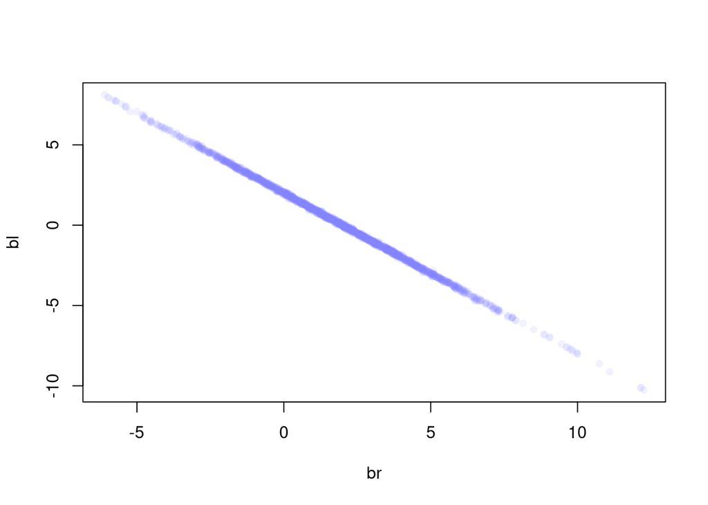

```r
post <- extract.samples(m5.8s)
plot( bl ~ br , post , col=col.alpha(rangi2,0.1) , pch=16 )
```

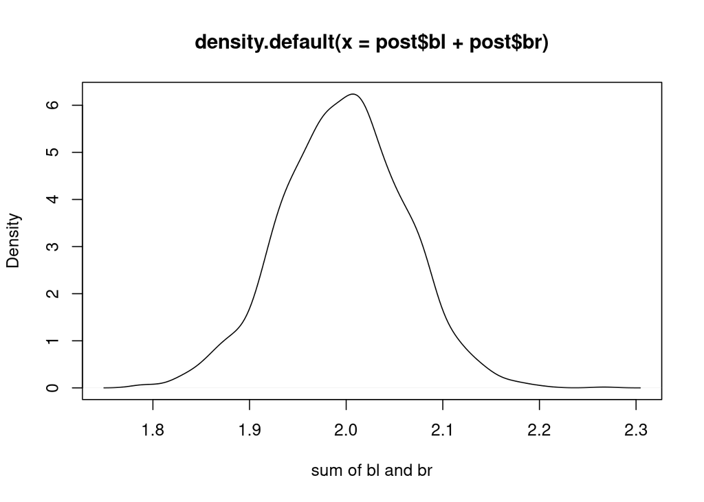

```r
plot(density(post$bl + post$br), xlab = "sum of bl and br")
```

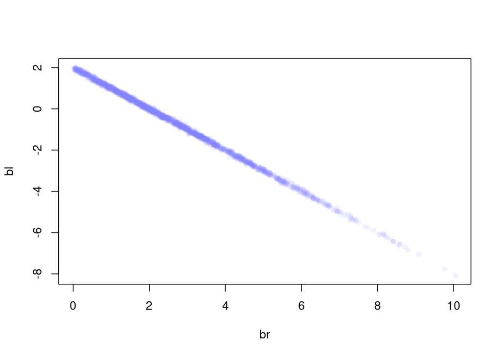

```r
post2 <- extract.samples(m5.8s2)
plot( bl ~ br , post2 , col=col.alpha(rangi2,0.1) , pch=16 )
```

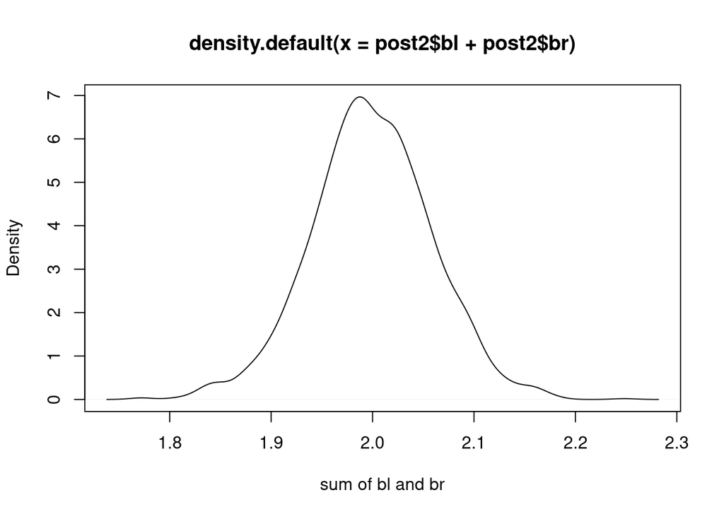

```r
plot(density(post2$bl + post2$br), xlab = "sum of bl and br")
```

###9H4

For the two models fit in the previous problem, use WAIC or PSIS to compare the effective numbers of parameters for each model. You will need to use log_lik=TRUE to instruct ulam to compute the terms that both WAIC and PSIS need. Which model has more effective parameters? Why?

**Answer:**

```r
compare(m5.8s, m5.8s2, func = PSIS )
```

```
##            PSIS       SE    dPSIS       dSE    pPSIS    weight
## m5.8s2 194.0981 11.29560 0.000000        NA 2.704996 0.6610908
## m5.8s  195.4344 11.15108 1.336318 0.5928245 3.283476 0.3389092
```

###9H5

Modify the Metropolis algorithm code from the chapter to handle the case that the island populations have a different distribution than the island labels. This means the island’s number will not be the same as its population.

**Answer:**

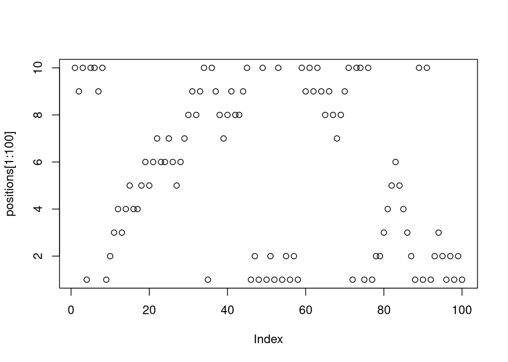

```r
num_weeks <- 1e5
positions <- rep(0,num_weeks)
current <- 10
pops <- c(800, 700, 600, 500, 400, 550, 600, 700, 800, 900)


for ( i in 1:num_weeks ) {
## record current position
positions[i] <- current
#prop_up <- current + 1
#prop_down <- current - 1
#if(prop_up > 10) prop_up <- 1
#if(prop_down < 1) prop_down <- 10
#
#prob_up <- pops[prop_up]/sum(pops[prop_up], pops[prop_down])
#prob_down <- 1 - prob_up
#probs <- c(prob_down, prob_up)
## flip coin to generate proposal
proposal <- current + sample( c(-1,1) , size=1)
## now make sure he loops around the archipelago
if ( proposal < 1 ) proposal <- 10
if ( proposal > 10 ) proposal <- 1
## move?
prob_move <- pops[proposal]/pops[current]
current <- ifelse( runif(1) < prob_move , proposal , current )
}

plot(positions[1:100])
```

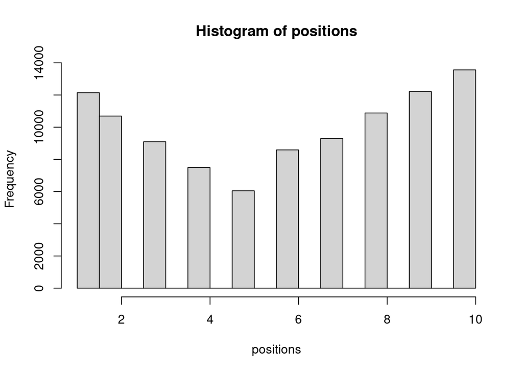

```r
hist(positions)
```

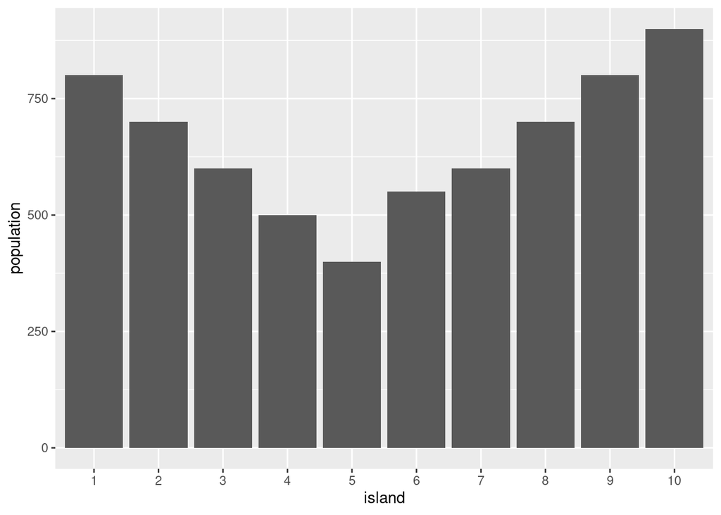

```r
# Compare to the proportion of population
ff <- data.frame(island=factor(1:10, levels=1:10), population=pops)
ggplot(ff) + geom_bar(aes(x=island, y=population), stat="identity")
```

###9H6

Modify the Metropolis algorithm code from the chapter to write your own simple MCMC estimator for globe tossing data and model from Chapter 2.

**Answer:**

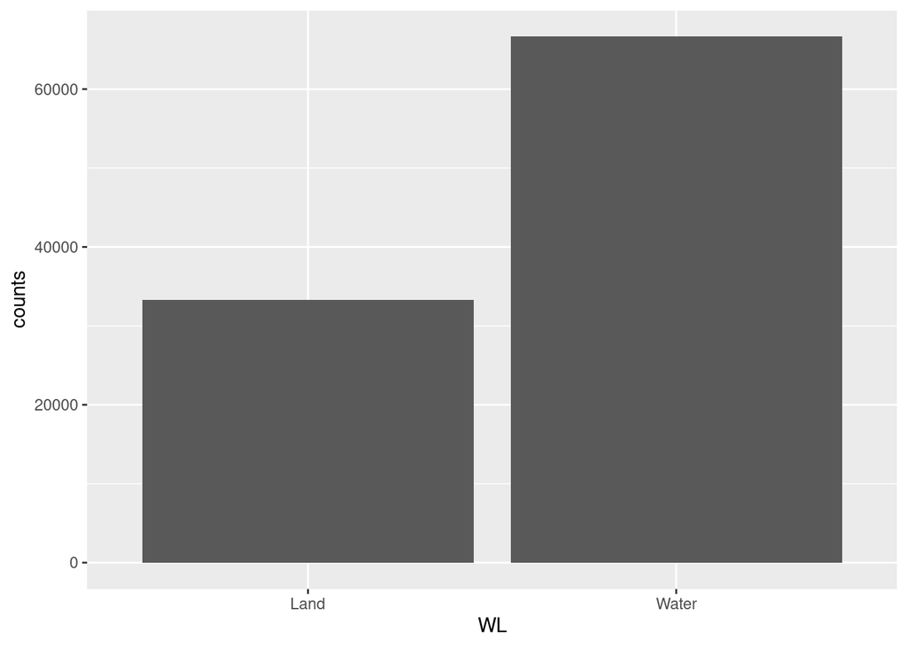

```r
num_throws <- 1e5
WLprop <- c(6,3)
positions <- rep(0,num_throws)
current <- 1
for ( i in 1:num_throws ) {
## record current position
positions[i] <- current
## flip coin to generate proposal
proposal <- current + sample( c(-1,1) , size=1 )
## now make sure he loops around the archipelago
if ( proposal < 1 ) proposal <- 2
if ( proposal > 2 ) proposal <- 1
## move?
prob_move <- WLprop[proposal]/WLprop[current]
current <- ifelse( runif(1) < prob_move , proposal , current )
}
ff <- data.frame(WL=c("Water", "Land"), counts=c(length(positions[positions == 1]), length(positions[positions == 2])))
ggplot(ff) + geom_bar(aes(x=WL, y=counts), stat="identity")
```

###9H7

Can you write your own Hamiltonian Monte Carlo algorithm for the globe tossing data, using the R code in the chapter? You will have to write your own functions for the likelihood and gradient, but you can use the HMC2 function.